# Decision Making Study

PSY 120L Reproducible Analysis Report

Author

Natalie Pomakian

Published

June 8, 2026

## About This Report

This report presents a reproducible analysis of our Decision making study.

## Study Overview

This Decision Makign study examines how participants make decisions, espeically risky ones, under different experimental conditions (presence/absence of peer norms).

## Setup and Software Environment

This section loads the packages necessary for this analysis. The “tidyverse” package is used for data visualization, “psych” is used for scale and reliability checks, “afex” is used for ANOVA, and “emmeans” is used for confidence intervals.

**Load Packages**

```r
library(tidyverse)  # data manipulation + plotting
library(psych)      # scale construction + reliability
library(afex)       # ANOVA models + effect sizes
library(emmeans)    # estimated marginal means + confidence intervals
```

## Data Source and Analysis Dataset

### Import Dataset

```r
study_raw <- read_csv("data/decision_making_data.csv")
```

### Check Imported Dataset

```r
dim(study_raw)
```

```
[1] 65 42
```

```r
names(study_raw)
```

```
 [1] "StartDate"             "EndDate"               "Status"
 [4] "IPAddress"             "Progress"              "Duration (in seconds)"
 [7] "Finished"              "RecordedDate"          "ResponseId"
[10] "ExternalReference"     "LocationLatitude"      "LocationLongitude"
[13] "DistributionChannel"   "UserLanguage"          "consent"
[16] "mc"                    "RTL_1"                 "RTL_2"
[19] "RTL_3"                 "RTL_4"                 "RTL_5"
[22] "PNR_1"                 "PNR_2"                 "PNR_3"
[25] "PNR_4"                 "PNR_5"                 "con_1"
[28] "con_2"                 "con_3"                 "con_4"
[31] "con_5"                 "con_6"                 "con_7"
[34] "con_8"                 "con_9"                 "con_10"
[37] "con_11"                "con_12"                "age"
[40] "academic_year"         "gender"                "condition"
```

```r
head(study_raw)
```

```
# A tibble: 6 × 42
  StartDate    EndDate Status IPAddress Progress Duration (in seconds…¹ Finished
  <chr>        <chr>    <dbl> <chr>        <dbl>                  <dbl>    <dbl>
1 5/5/26 20:03 5/5/26…      0 72.205.8…      100                    146        1
2 5/6/26 10:41 5/6/26…      0 169.231.…      100                    298        1
3 5/6/26 14:03 5/6/26…      0 169.231.…      100                    874        1
4 5/6/26 15:03 5/6/26…      0 169.231.…      100                    211        1
5 5/5/26 19:04 5/6/26…      0 68.6.116…      100                  83227        1
6 5/6/26 22:11 5/6/26…      0 184.187.…      100                    261        1
# ℹ abbreviated name: ¹`Duration (in seconds)`
# ℹ 35 more variables: RecordedDate <chr>, ResponseId <chr>,
#   ExternalReference <lgl>, LocationLatitude <dbl>, LocationLongitude <dbl>,
#   DistributionChannel <chr>, UserLanguage <chr>, consent <dbl>, mc <dbl>,
#   RTL_1 <dbl>, RTL_2 <dbl>, RTL_3 <dbl>, RTL_4 <dbl>, RTL_5 <dbl>,
#   PNR_1 <dbl>, PNR_2 <dbl>, PNR_3 <dbl>, PNR_4 <dbl>, PNR_5 <dbl>,
#   con_1 <dbl>, con_2 <dbl>, con_3 <dbl>, con_4 <dbl>, con_5 <dbl>, …
```

This section imports the data set from our study and creates a smaller dataset with only the relevant varibales needed for this study.

### Create Analysis Dataset

```r
study_vars <- c(
  "condition",  # experimental condition variable
  "age", "academic_year", "gender",

          "RTL_1", "RTL_2", "RTL_3", "RTL_4", "RTL_5",

          "PNR_1", "PNR_2", "PNR_3", "PNR_4", "PNR_5",

          "con_1", "con_2", "con_3", "con_4", "con_5",
          "con_6", "con_7", "con_8", "con_9", "con_10",
          "con_11", "con_12"
)

study_data <- study_raw %>%
  select(all_of(study_vars)) %>%
  mutate(across(everything(), as.numeric))
```

### Check Analysis Dataset

```r
length(study_vars)
```

```
[1] 26
```

```r
dim(study_data)
```

```
[1] 65 26
```

```r
names(study_data)
```

```
 [1] "condition"     "age"           "academic_year" "gender"
 [5] "RTL_1"         "RTL_2"         "RTL_3"         "RTL_4"
 [9] "RTL_5"         "PNR_1"         "PNR_2"         "PNR_3"
[13] "PNR_4"         "PNR_5"         "con_1"         "con_2"
[17] "con_3"         "con_4"         "con_5"         "con_6"
[21] "con_7"         "con_8"         "con_9"         "con_10"
[25] "con_11"        "con_12"
```

The output above confirms that our analysis dataset was compiled correctly. The output gives us the number of selected variables, the dimension of the dataset, and the variable names included in our final dataset.

## Variable Preparation

This section prepares the variables needed for analysis. The experimental condition variable is converted into a label in order to easily interpret the output.

### Prepare Participant ID and Experimental Condition

```r
study_data <- study_data %>%
  mutate(
    id = row_number(),
    condition= factor(
      condition,
      levels = c(0, 1),
      labels = c("Risk-Avoiding", "Risk-Normalizing")
    )
  )
```

This section prepares the variables needed for analysis. The experimental condition variable is converted into a label in order to easily interpret the output.

### Check Experimental Condition Coding

```r
study_data %>%
  count(condition) %>%
  knitr::kable(
    col.names = c("Condition", "n")
  )
```

| Condition | n |
| --- | --- |
| Risk-Avoiding | 31 |
| Risk-Normalizing | 33 |
| NA | 1 |

### Check Prepared Analysis Dataset

```r
dim(study_data)
```

```
[1] 65 27
```

```r
names(study_data)
```

```
 [1] "condition"     "age"           "academic_year" "gender"
 [5] "RTL_1"         "RTL_2"         "RTL_3"         "RTL_4"
 [9] "RTL_5"         "PNR_1"         "PNR_2"         "PNR_3"
[13] "PNR_4"         "PNR_5"         "con_1"         "con_2"
[17] "con_3"         "con_4"         "con_5"         "con_6"
[21] "con_7"         "con_8"         "con_9"         "con_10"
[25] "con_11"        "con_12"        "id"
```

The output above confirms that the dataset analysis includes the expected number of variables and observations after adding the participant ID as well as recoding the experimental condition variables.

### Reverse-Code Scale Items

Some conscientiousness items were reverse coded in order to ensure all items line up before curating the final scale score.

```r
study_data <- study_data %>%
  mutate(
    con_1r = 6 - con_1,
    con_2r = 6 - con_2,
    con_5r = 6 - con_5,
    con_6r = 6 - con_6,
    con_10r = 6 - con_10,
    con_12r = 6 - con_12
  )
```

### Check Reverse Coding

```r
study_data %>%
  select(con_1, con_1r) %>%
  head(10) %>%
  knitr::kable()
```

| con_1 | con_1r |
| --- | --- |
| 4 | 2 |
| 1 | 5 |
| 1 | 5 |
| 1 | 5 |
| 2 | 4 |
| 4 | 2 |
| 2 | 4 |
| 1 | 5 |
| 2 | 4 |
| 2 | 4 |

### Create Scale Scores

This section computes composite scale scores for each of the measures used in this study. The risk-taking likelihood score is averaged across five items, the peer norm resistance score is averaged across five items, and the conscientiousness score is averaged across twelve items, including the six reverse-coded items. Row means are used so that participants with one missing item are not dropped entirely.

```r
# Define risk-taking likelihood items
risk_taking_items <- c("RTL_1", "RTL_2", "RTL_3", "RTL_4", "RTL_5")

# Define peer norm resistance items
peer_norm_resistance_items <- c("PNR_1", "PNR_2", "PNR_3", "PNR_4", "PNR_5")

# Define conscientiousness items
conscientiousness_items <- c("con_1r", "con_2r", "con_3", "con_4", "con_5r", "con_6r", "con_7", "con_8", "con_9", "con_10r", "con_11", "con_12r")

# Create scale scores
study_data <- study_data %>%
  mutate(
    risk_taking = rowMeans(across(all_of(risk_taking_items)), na.rm = TRUE),
    peer_norm_resistance = rowMeans(across(all_of(peer_norm_resistance_items)), na.rm = TRUE),
    conscientiousness = rowMeans(across(all_of(conscientiousness_items)), na.rm = TRUE)
  )
```

### Check Scale Scores

```r
study_data %>%
  select(risk_taking, peer_norm_resistance, conscientiousness) %>%
  summary()
```

```
  risk_taking   peer_norm_resistance conscientiousness
 Min.   :1.00   Min.   :3.400        Min.   :2.333
 1st Qu.:2.20   1st Qu.:5.000        1st Qu.:3.250
 Median :2.80   Median :6.000        Median :3.667
 Mean   :2.84   Mean   :5.698        Mean   :3.614
 3rd Qu.:3.40   3rd Qu.:6.400        3rd Qu.:3.917
 Max.   :5.60   Max.   :7.000        Max.   :4.833
```

```r
study_data %>%
  summarise(
    risk_taking_missing = mean(is.na(risk_taking)),
    peer_norm_resistance_missing = mean(is.na(peer_norm_resistance)),
    conscientiousness_missing = mean(is.na(conscientiousness))
  ) %>%
  knitr::kable()
```

| risk_taking_missing | peer_norm_resistance_missing | conscientiousness_missing |
| --- | --- | --- |
| 0 | 0 | 0 |

The statistics above show the minimum, maximum, median, and mean for each of the scale scores, giving a quick overview of the distribution of responses. The missing-data table below confirms the proportion of missing values for each scale. Values of 0 indicate no missing data, suggesting all participants contributed complete responses to each scale.

### Create Concientiousness Groups

```r
conscientiousness_median <- median(study_data$conscientiousness, na.rm = TRUE)

study_data <- study_data %>%
  mutate(
    conscientiousness_msplit = if_else(conscientiousness <= conscientiousness_median, "Low", "High"),
    conscientiousness_msplit = factor(conscientiousness_msplit, levels = c("Low", "High"))
  )

conscientiousness_median
```

```
[1] 3.666667
```

```r
study_data %>%
  count(conscientiousness_msplit) %>%
  knitr::kable()
```

| conscientiousness_msplit | n |
| --- | --- |
| Low | 35 |
| High | 30 |

The output above shows the median conscientiousness score used as the split point, followed by a table simply showing the number of participants assigned to each group. The two groups are roughly equal in size, which would indicate the median split divided the sample evenly.

### Check Scale Reliability

This section looks at how consistent each scale is. Cronbach’s alpha measures the average correlation between items in a scale. McDonald’s omega offers a more flexible estimate. It considers that not all items may contribute equally.

```r
risk_taking_item_df <- study_data %>% select(all_of(risk_taking_items))
peer_norm_resistance_item_df <- study_data %>% select(all_of(peer_norm_resistance_items))
conscientiousness_item_df <- study_data %>% select(all_of(conscientiousness_items))

risk_taking_alpha <- psych::alpha(risk_taking_item_df)
```

```
Some items ( RTL_5 ) were negatively correlated with the first principal component and
probably should be reversed.
To do this, run the function again with the 'check.keys=TRUE' option
```

```r
risk_taking_omega <- psych::omega(risk_taking_item_df, plot = FALSE)

peer_norm_resistance_alpha <- psych::alpha(peer_norm_resistance_item_df)
peer_norm_resistance_omega <- psych::omega(peer_norm_resistance_item_df, plot = FALSE)

conscientiousness_alpha <- psych::alpha(conscientiousness_item_df)
conscientiousness_omega <- psych::omega(conscientiousness_item_df, plot = FALSE)

reliability_table <- tibble(
  scale = c("Risk-Taking Likelihood", "Peer Norm Resistance", "Conscientiousness"),
  alpha = c(
    risk_taking_alpha$total$raw_alpha,
    peer_norm_resistance_alpha$total$raw_alpha,
    conscientiousness_alpha$total$raw_alpha
  ),
  omega = c(
    risk_taking_omega$omega.tot,
    peer_norm_resistance_omega$omega.tot,
    conscientiousness_omega$omega.tot
  )
)

reliability_table %>%
  mutate(
    alpha = round(alpha, 2),
    omega = round(omega, 2)
  ) %>%
  knitr::kable(
    col.names = c("Scale", "Cronbach's alpha", "McDonald's omega")
  )
```

| Scale | Cronbach’s alpha | McDonald’s omega |
| --- | --- | --- |
| Risk-Taking Likelihood | 0.37 | 0.46 |
| Peer Norm Resistance | 0.82 | 0.89 |
| Conscientiousness | 0.77 | 0.84 |

The reliability table above reports Cronbach’s alpha and McDonald’s omega for the Risk-Taking Likelihood, Peer Norm Resistance, and Conscientiousness scales. Scales with acceptable reliability are considered internally consistent.

## Descriptive Statistics

This section summarizes the distribution of scale scores and the demographic composition of the sample. Descriptive statistics help provide an overview of the data before checking everything else, and they can help identify any abnormal patterns such as extreme means or high variability that might alter the results.

### Scale Score Descriptives

```r
study_data %>%
  select(risk_taking, peer_norm_resistance, conscientiousness) %>%
  psych::describe() %>%
  knitr::kable(digits = 2)
```

|  | vars | n | mean | sd | median | trimmed | mad | min | max | range | skew | kurtosis | se |
| --- | --- | --- | --- | --- | --- | --- | --- | --- | --- | --- | --- | --- | --- |
| risk_taking | 1 | 65 | 2.84 | 1.00 | 2.80 | 2.78 | 0.89 | 1.00 | 5.60 | 4.6 | 0.56 | -0.14 | 0.12 |
| peer_norm_resistance | 2 | 65 | 5.70 | 0.93 | 6.00 | 5.76 | 0.89 | 3.40 | 7.00 | 3.6 | -0.53 | -0.39 | 0.12 |
| conscientiousness | 3 | 65 | 3.61 | 0.56 | 3.67 | 3.61 | 0.49 | 2.33 | 4.83 | 2.5 | -0.04 | -0.52 | 0.07 |

The table above reports the mean, standard deviation, median, minimum, maximum, skewness, and kurtosis for each of the scale scores. These values describe risk-taking likelihood, peer norm resistance, and conscientiousness in the sample. This can be used to examine whether the distributions appear normal.

### Sample Composition

```r
study_data %>%
  summarise(
    mean_age = mean(age, na.rm = TRUE),
    sd_age = sd(age, na.rm = TRUE),
    min_age = min(age, na.rm = TRUE),
    max_age = max(age, na.rm = TRUE)
  ) %>%
  knitr::kable(digits = 2)
```

| mean_age | sd_age | min_age | max_age |
| --- | --- | --- | --- |
| 21.65 | 3.37 | 18 | 45 |

```r
study_data %>%
  count(academic_year) %>%
  mutate(percent = round(100 * n / sum(n), 1)) %>%
  knitr::kable()
```

| academic_year | n | percent |
| --- | --- | --- |
| 1 | 4 | 6.2 |
| 2 | 6 | 9.2 |
| 3 | 14 | 21.5 |
| 4 | 38 | 58.5 |
| 5 | 3 | 4.6 |

```r
study_data %>%
  count(gender) %>%
  mutate(percent = round(100 * n / sum(n), 1)) %>%
  knitr::kable()
```

| gender | n | percent |
| --- | --- | --- |
| 1 | 14 | 21.5 |
| 2 | 50 | 76.9 |
| 4 | 1 | 1.5 |

## Correlations Among the DVs

This section examines the correlation between risk-taking likelihood and peer norm resistance. A significant positive correlation would indicate that participants who score higher on risk-taking also score higher on peer norm resistance. A negative correlation would indicate the opposite effect.

```r
study_data %>%
  select(risk_taking, peer_norm_resistance) %>%
  psych::corr.test()
```

```
Call:psych::corr.test(x = .)
Correlation matrix
                     risk_taking peer_norm_resistance
risk_taking                 1.00                -0.25
peer_norm_resistance       -0.25                 1.00
Sample Size
[1] 65
Probability values (Entries above the diagonal are adjusted for multiple tests.)
                     risk_taking peer_norm_resistance
risk_taking                 0.00                 0.05
peer_norm_resistance        0.05                 0.00

 To see confidence intervals of the correlations, print with the short=FALSE option
```

## Primary Analyses

This section reports the main inferential analyses of the study. Two separate 2 × 2 between-subjects ANOVAs are conducted, one for each dependent variable, with experimental condition (Risk-Avoiding vs. Risk-Normalizing) and conscientiousness level (Low vs. High) as the between-subjects factors. Each model tests for a main effect of condition, a main effect of conscientiousness group, and their interaction. Estimated marginal means are then computed to describe group differences in more detail.

### Risk Taking Model

This model tests whether risk-taking likelihood differs as a function of experimental condition, conscientiousness group, or their interaction. A significant main effect of condition would indicate that participants who read risk-normalizing peer norms reported higher or lower risk-taking than those who read risk-avoiding norms. A significant main effect of conscientiousness would indicate that participants higher in conscientiousness differ systematically in risk-taking. A significant interaction would indicate that the effect of condition on risk-taking depends on a participant’s level of conscientiousness.

```r
a1_risk <- afex::aov_ez(
  id = "id",
  dv = "risk_taking",
  between = c("condition", "conscientiousness_msplit"),
  data = study_data
)

a1_risk
```

```
Anova Table (Type 3 tests)

Response: risk_taking
                              Effect    df  MSE      F   ges p.value
1                          condition 1, 60 0.93 4.55 *  .070    .037
2           conscientiousness_msplit 1, 60 0.93 3.41 +  .054    .070
3 condition:conscientiousness_msplit 1, 60 0.93   0.01 <.001    .931
---
Signif. codes:  0 '***' 0.001 '**' 0.01 '*' 0.05 '+' 0.1 ' ' 1
```

The ANOVA table above reports the F-statistic, degrees of freedom, p-value, and generalized eta-squared (ges) effect size for each effect in the risk-taking model. The p-value indicates a statistically significant effect. The ges value reflects how much variance in risk-taking likelihood is explained by each factor.

```r
emmeans(a1_risk, ~ condition)
```

```
 condition        emmean    SE df lower.CL upper.CL
 Risk-Avoiding      3.06 0.174 60     2.72     3.41
 Risk-Normalizing   2.54 0.172 60     2.20     2.89

Results are averaged over the levels of: conscientiousness_msplit
Confidence level used: 0.95
```

```r
emmeans(a1_risk, ~ conscientiousness_msplit)
```

```
 conscientiousness_msplit emmean    SE df lower.CL upper.CL
 Low                        3.03 0.165 60     2.70     3.36
 High                       2.58 0.180 60     2.22     2.94

Results are averaged over the levels of: condition
Confidence level used: 0.95
```

```r
emmeans(a1_risk, ~ condition * conscientiousness_msplit)
```

```
 condition        conscientiousness_msplit emmean    SE df lower.CL upper.CL
 Risk-Avoiding    Low                        3.28 0.249 60     2.78     3.78
 Risk-Normalizing Low                        2.78 0.216 60     2.35     3.21
 Risk-Avoiding    High                       2.85 0.241 60     2.37     3.33
 Risk-Normalizing High                       2.31 0.268 60     1.77     2.84

Confidence level used: 0.95
```

The estimated marginal means tables above report the model-estimated mean risk-taking likelihood score for each experimental condition and each conscientiousness group. These means are adjusted for the other factor in the model and are used to interpret the size of any significant effects from the ANOVA.

### Peer Norm Resistance Model

This model tests whether peer norm resistance differs as a function of experimental condition, conscientiousness group, or their interaction. A significant main effect of condition would suggest that exposure to risk-normalizing versus risk-avoiding peer norms influences participants’ resistance to those norms. A significant interaction would indicate that this effect is moderated by conscientiousness, such that the impact of the peer norm manipulation on resistance differs between low and high conscientiousness participants.

```r
a1_peer <- afex::aov_ez(
  id = "id",
  dv = "peer_norm_resistance",
  between = c("condition", "conscientiousness_msplit"),
  data = study_data
)

a1_peer
```

```
Anova Table (Type 3 tests)

Response: peer_norm_resistance
                              Effect    df  MSE    F  ges p.value
1                          condition 1, 60 0.76 1.51 .025    .224
2           conscientiousness_msplit 1, 60 0.76 2.49 .040    .120
3 condition:conscientiousness_msplit 1, 60 0.76 2.34 .038    .131
---
Signif. codes:  0 '***' 0.001 '**' 0.01 '*' 0.05 '+' 0.1 ' ' 1
```

The ANOVA table above reports the F-statistic, degrees of freedom, p-value, and generalized eta-squared effect size for each effect in the peer norm resistance model. As with the risk-taking model, p-values below .05 indicate statistically significant effects, and the effect size values help understand the practical significance of those effects.

### Estimated Means for Peer Norm Resistance

```r
emmeans(a1_peer, ~ condition)
```

```
 condition        emmean    SE df lower.CL upper.CL
 Risk-Avoiding      5.63 0.157 60     5.32     5.95
 Risk-Normalizing   5.90 0.155 60     5.59     6.21

Results are averaged over the levels of: conscientiousness_msplit
Confidence level used: 0.95
```

```r
emmeans(a1_peer, ~ conscientiousness_msplit)
```

```
 conscientiousness_msplit emmean    SE df lower.CL upper.CL
 Low                        5.59 0.149 60     5.30     5.89
 High                       5.94 0.163 60     5.62     6.27

Results are averaged over the levels of: condition
Confidence level used: 0.95
```

```r
emmeans(a1_peer, ~ condition * conscientiousness_msplit)
```

```
 condition        conscientiousness_msplit emmean    SE df lower.CL upper.CL
 Risk-Avoiding    Low                        5.63 0.225 60     5.18     6.08
 Risk-Normalizing Low                        5.56 0.195 60     5.17     5.95
 Risk-Avoiding    High                       5.64 0.218 60     5.20     6.07
 Risk-Normalizing High                       6.25 0.242 60     5.76     6.73

Confidence level used: 0.95
```

The estimated means tables above report the model-estimated mean peer norm resistance score broken down by experimental condition alone, conscientiousness group alone, and the conscientious levels. These values allow for the comparison of group differences on peer norm resistance and help us interpret any significant effects from the ANOVA.

## Figures

This section produces bar graphs that visually show the interaction between experimental condition and conscientiousness group for each dependent variable. Each plot shows the estimated marginal means on the y-axis, with the two experimental conditions on the x-axis and separate bars for the Low and High conscientiousness groups. The error bars represent 95% confidence intervals.

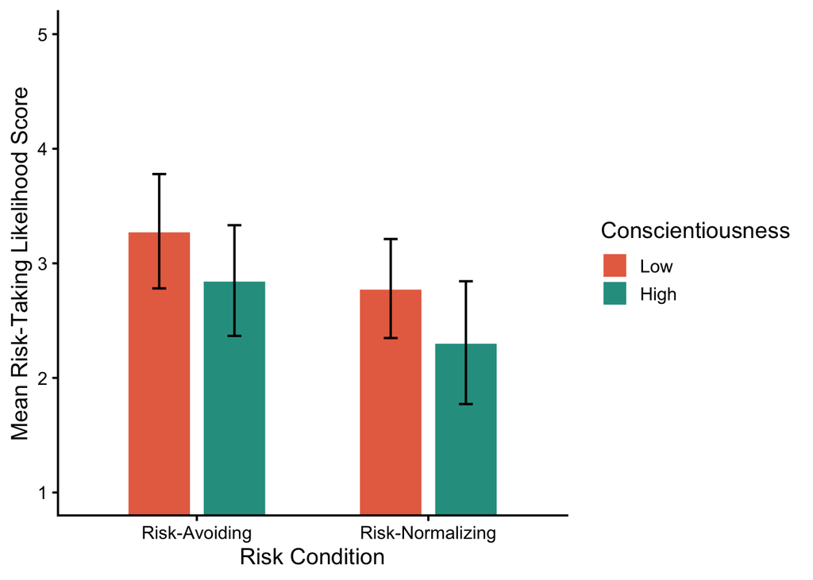

```r
risk_cell_means <- as.data.frame(
  emmeans(a1_risk, ~ condition * conscientiousness_msplit)
)

p_risk_bar <- ggplot(
  risk_cell_means,
  aes(
    x = condition,
    y = emmean,
    fill = conscientiousness_msplit
  )
) +
  geom_col(
    position = position_dodge(width = 0.65),
    width = 0.55,
    color = "white"
  ) +
  geom_errorbar(
    aes(
      ymin = lower.CL,
      ymax = upper.CL
    ),
    position = position_dodge(width = 0.65),
    width = 0.12,
    linewidth = 0.7
  ) +
  labs(
    x = "Risk Condition",
    y = "Mean Risk-Taking Likelihood Score",
    fill = "Conscientiousness"
  ) +
  scale_fill_manual(
    values = c(
      "Low" = "#E76F51",  # YOU CAN CHANGE THESE TWO HEX VALUES TO MATCH YOUR POSTER!
      "High" = "#2A9D8F"  # YOU CAN CHANGE THESE TWO HEX VALUES TO MATCH YOUR POSTER!
    )
  ) +
  scale_y_continuous(breaks = 1:5) +
  coord_cartesian(ylim = c(1, 5)) +
  theme_classic(base_size = 14)

p_risk_bar
```

The graph above shows the estimated mean risk-taking likelihood scores for each combination of experimental condition and conscientiousness group. The x-axis distinguishes between the Risk-Avoiding and Risk-Normalizing conditions, and the bar colors differentiate between Low (orange) and High (teal) conscientiousness groups. This figure allows for a visual inspection of the main effects and any potential interaction between condition and conscientiousness on risk-taking.

### Peer Norm Resistance Interaction Plot

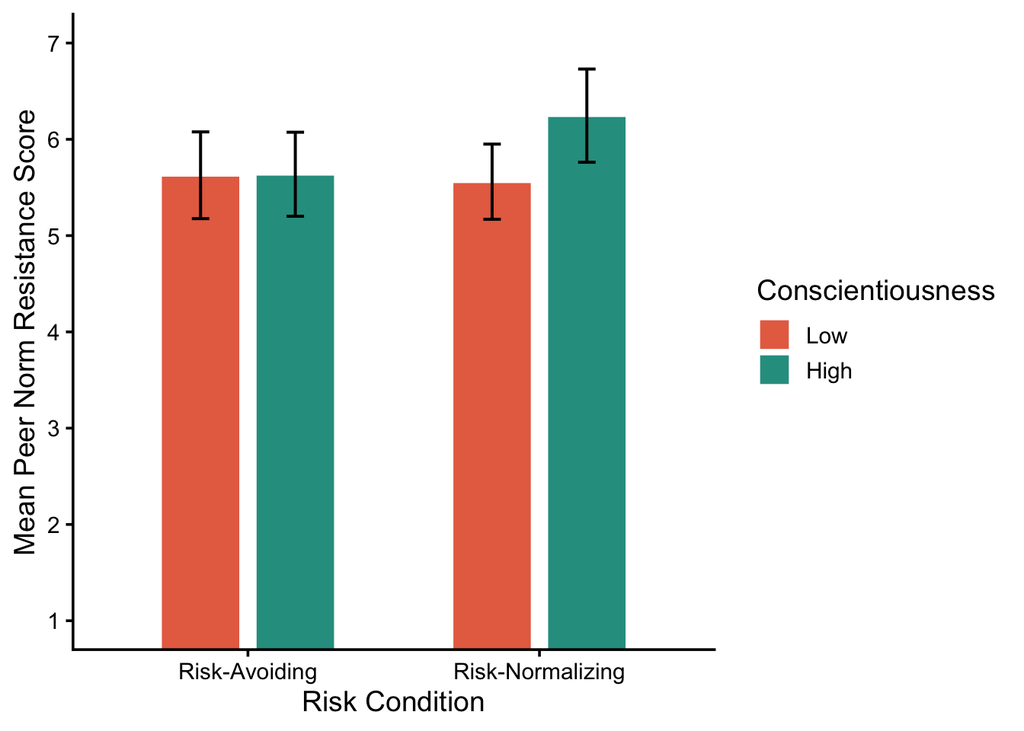

```r
peer_cell_means <- as.data.frame(
  emmeans(a1_peer, ~ condition * conscientiousness_msplit)
)

p_peer_bar <- ggplot(
  peer_cell_means,
  aes(
    x = condition,
    y = emmean,
    fill = conscientiousness_msplit
  )
) +
  geom_col(
    position = position_dodge(width = 0.65),
    width = 0.55,
    color = "white"
  ) +
  geom_errorbar(
    aes(
      ymin = lower.CL,
      ymax = upper.CL
    ),
    position = position_dodge(width = 0.65),
    width = 0.12,
    linewidth = 0.7
  ) +
  labs(
    x = "Risk Condition",
    y = "Mean Peer Norm Resistance Score",
    fill = "Conscientiousness"
  ) +
  scale_fill_manual(
    values = c(
      "Low" = "#E76F51",  # YOU CAN CHANGE THESE TWO HEX VALUES TO MATCH YOUR POSTER!
      "High" = "#2A9D8F"  # YOU CAN CHANGE THESE TWO HEX VALUES TO MATCH YOUR POSTER!
    )
  ) +
  scale_y_continuous(breaks = 1:7) +
  coord_cartesian(ylim = c(1, 7)) +
  theme_classic(base_size = 14)

p_peer_bar
```

The bar graph above displays the estimated mean peer norm resistance scores for each combination of experimental condition and conscientiousness group, with 95% confidence intervals shown as error bars. The y-axis spans the full 1–7 scale range. As with the risk-taking plot, bar colors distinguish Low (orange) from High (teal) conscientiousness groups, and the x-axis separates the two experimental conditions. This figure allows for visual inspection of main effects and any potential interaction on peer norm resistance.

### Export Figures

```r
if (!dir.exists("figures")) {
  dir.create("figures")
}

ggsave(
  filename = "figures/risk_taking_interaction_plot.svg",
  plot = p_risk_bar,
  width = 7,
  height = 5
)

ggsave(
  filename = "figures/peer_norm_resistance_interaction_plot.svg",
  plot = p_peer_bar,
  width = 7,
  height = 5
)
```

The script above saves both interaction plots as SVG files to the `figures/` folder in the project directory. SVG is a vector format, meaning the figures will remain crisp and sharp at any size, which makes them well-suited for use in our poster.

## Results Summary

This report looked at how exposure to peer norms, whether avoiding or normalizing risk, affects two outcomes: the likelihood of risk-taking and resistance to peer norms. Conscientiousness was included as a moderating variable by dividing participants into low and high groups based on a median split. We conducted separate two-way ANOVAs for each outcome and calculated estimated marginal means to show group differences. Interaction plots were created to illustrate how the effect of the peer norm condition may change based on participants’ level of conscientiousness. Together, these analyses explore whether peer norm framing affects decision-making tendencies and whether individual differences in conscientiousness influence that effect.